**A Comparative Analysis of ARIMA, Exponential Smoothing and Prophet on the Forecasting of Ghana’s GDP(1960 - 2023)**

This is a comparison of model performance between traditional Time Series forecasting methods (ARIMA & ETS) and Modern Machine Learning forecasting methods (Prophet) on the Mean Absolute Error (MAE) and Root Mean Square Error (RMSE) evaluation metrics.

Load the necessary packages

```r
library(tibble)
```

```r
library(ggplot2)
library(astsa)
library(forecast)
library(tseries)
library(prophet)
```

Loading the data

```r
setwd("your working directory") #Set your working directory containing the file you want to read
GDP_Data <- read.csv("Ghana_GDP A.csv")
```

Converting the loaded GDP data into a Time Series (ts) data type

```r
gdp_ts=ts(GDP_Data$gdp, start=c(1960,1), frequency=1)
gdp_ts
```

```
## Time Series:
## Start = 1960
## End = 2023
## Frequency = 1
##  [1]  1217  1303  1383  1541  1731  2053  2126  1747  1667  1962  2215  2417
## [13]  2112  3007  2894  2810  2765  3189  3662  4020  4445  4222  4036  4057
## [25]  4412  4504  5736  5075  5198  5252  5889  6603  6416  5969  5446  6464
## [37]  6933  6891  7482  7718  4983  5315  6166  7633  8881 10745 20885 24827
## [49] 28679 26049 32198 39337 41272 62825 54783 49406 56165 60406 67299 68338
## [61] 70043 79524 74263 76370
```

Explore the Data (Simple Exploratory data analysis)

```r
summary(gdp_ts)
```

```
##    Min. 1st Qu.  Median    Mean 3rd Qu.    Max.
##    1217    2979    5591   17734   25133   79524
```

Add the Time Series data into a data frame so that it’s easy to plot it in a visual and also split it to to train and test sets

```r
gdp_d.f <- data.frame(
  Year = as.numeric(time(gdp_ts)),
  GDP = as.numeric(gdp_ts)
)
```

Let’s Visualize our Series with ggplot2

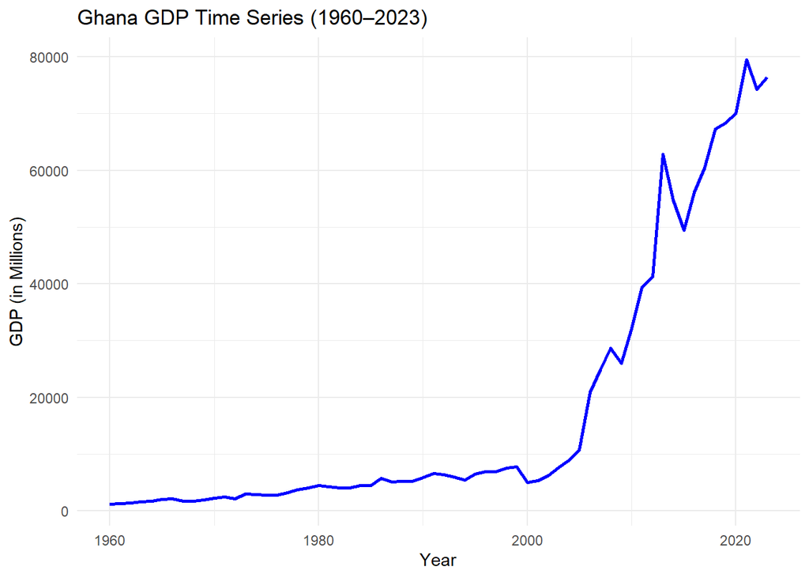

```r
library(ggplot2)
ggplot(gdp_d.f, aes(x = Year, y = GDP)) +
  geom_line(color = "blue", linewidth = 1) +
  labs(title = "Ghana GDP Time Series (1960–2023)",
       x = "Year",
       y = "GDP (in Millions)") +
  theme_minimal()
```

Split the GDP Time Series into Training and Testing sets. We’ll use 1960 - 2021 for training and then test with 2022 and 2023

```r
train_ts = window(gdp_ts, end = c(1960 + length(gdp_ts) - 3))
test_ts = window(gdp_ts, start = c(1960 + length(gdp_ts) - 2))
print(train_ts)
```

```
## Time Series:
## Start = 1960
## End = 2021
## Frequency = 1
##  [1]  1217  1303  1383  1541  1731  2053  2126  1747  1667  1962  2215  2417
## [13]  2112  3007  2894  2810  2765  3189  3662  4020  4445  4222  4036  4057
## [25]  4412  4504  5736  5075  5198  5252  5889  6603  6416  5969  5446  6464
## [37]  6933  6891  7482  7718  4983  5315  6166  7633  8881 10745 20885 24827
## [49] 28679 26049 32198 39337 41272 62825 54783 49406 56165 60406 67299 68338
## [61] 70043 79524
```

```r
print(test_ts)
```

```
## Time Series:
## Start = 2022
## End = 2023
## Frequency = 1
## [1] 74263 76370
```

1. **Start the ARIMA Models process**

**Checking for Stationarity/Differencing**  
Here, we are determining how many times the series should be differenced to achieve stationarity, but first, we check for stationarity with two tests.

```r
adf.test(train_ts)  #Augmented Dickey Fuller Test for stationarity
```

```
##
##  Augmented Dickey-Fuller Test
##
## data:  train_ts
## Dickey-Fuller = 0.95332, Lag order = 3, p-value = 0.99
## alternative hypothesis: stationary
```

```r
kpss.test(train_ts) #KPSS test for stationarity
```

```
##
##  KPSS Test for Level Stationarity
##
## data:  train_ts
## KPSS Level = 1.1375, Truncation lag parameter = 3, p-value = 0.01
```

Both tests suggest that the series is not stationary and so we have to difference it

We have to determine how many times we should difference the series to make it stationary so that we can fit it to the ARIMA modelling

```r
ndiffs(train_ts) #number of times to difference the series
```

```
## [1] 2
```

We have to difference the series **twice** in order to achieve stationarity.

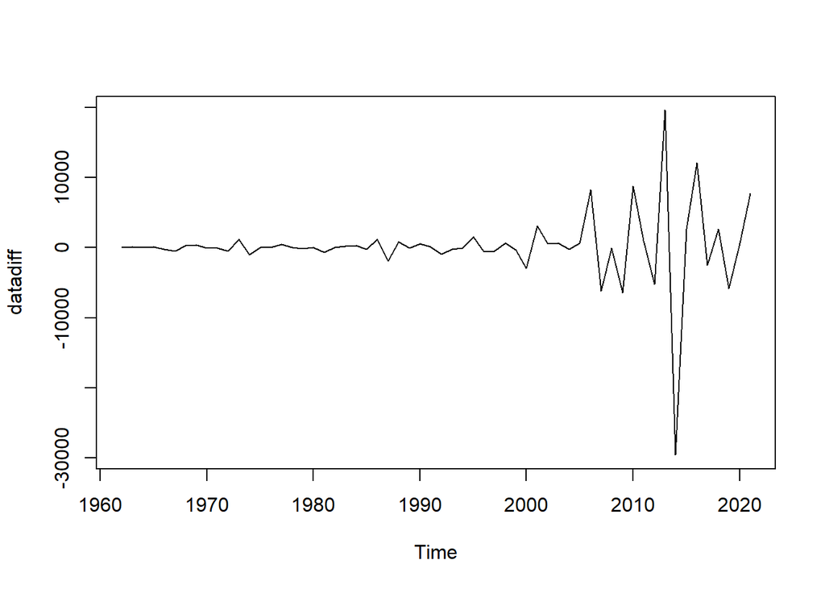

```r
datadiff=diff(train_ts, differences = 2) #two order differencing
plot(datadiff) #visualize the differenced series
```

The Autocorrelation function (ACF) and the Partial autocorrelation function (PACF) plots of the differenced series help to determine the suitable AR() and MA() orders for the best fit of the ARMA model

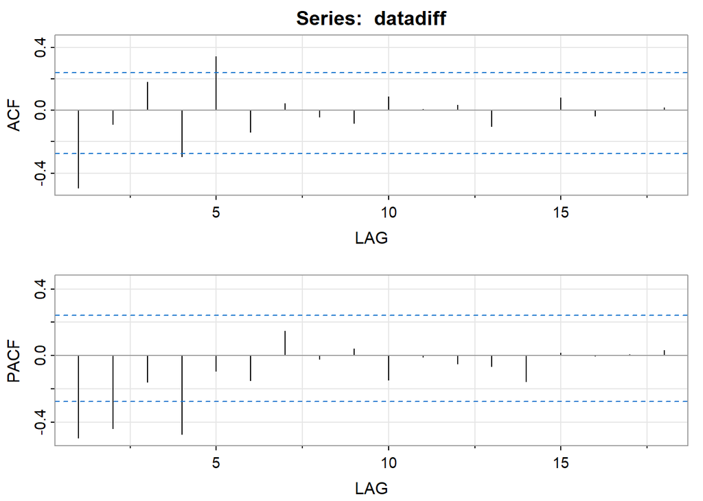

```
##       [,1]  [,2]  [,3]  [,4]  [,5]  [,6] [,7]  [,8]  [,9] [,10] [,11] [,12]
## ACF  -0.49 -0.09  0.18 -0.30  0.34 -0.14 0.04 -0.04 -0.08  0.09  0.01  0.03
## PACF -0.49 -0.44 -0.16 -0.47 -0.09 -0.15 0.15 -0.02  0.04 -0.15 -0.01 -0.05
##      [,13] [,14] [,15] [,16] [,17] [,18]
## ACF  -0.10  0.00  0.08 -0.04  0.00  0.02
## PACF -0.07 -0.16  0.02  0.00  0.01  0.03
```

```r
acf2(datadiff)
```

We can also use the **auto.arima** function from the **forecast** library to determine the suitable **ARIMA** model for forecasting. We use the **train_ts** series since we don’t want to expose our testing (test_ts) data to the model for evaluation reasons.

```r
auto.arima(train_ts, seasonal = FALSE, stepwise = FALSE, approximation = FALSE)
```

```
## Series: train_ts
## ARIMA(1,2,3)
##
## Coefficients:
##           ar1      ma1      ma2     ma3
##       -0.6051  -0.3977  -0.8519  0.4929
## s.e.   0.1503   0.2039   0.1796  0.1554
##
## sigma^2 = 12564114:  log likelihood = -575.27
## AIC=1160.54   AICc=1161.65   BIC=1171.01
```

It Suggests ARIMA(1,2,3), excellent correspondence with the differencing order(**I**) of 2 that we determined earlier.

We go ahead to fit the training data series to the suggested forecasting model, ARIMA(1,2,3) using the **sarima** function from the **astsa** package.

```
## <><><><><><><><><><><><><><>
##
## Coefficients:
##     Estimate     SE t.value p.value
## ar1  -0.6051 0.1503 -4.0252  0.0002
## ma1  -0.3977 0.2039 -1.9506  0.0561
## ma2  -0.8519 0.1796 -4.7447  0.0000
## ma3   0.4929 0.1554  3.1714  0.0025
##
## sigma^2 estimated as 11726506 on 56 degrees of freedom
##
## AIC = 19.34238  AICc = 19.3545  BIC = 19.51691
##
```

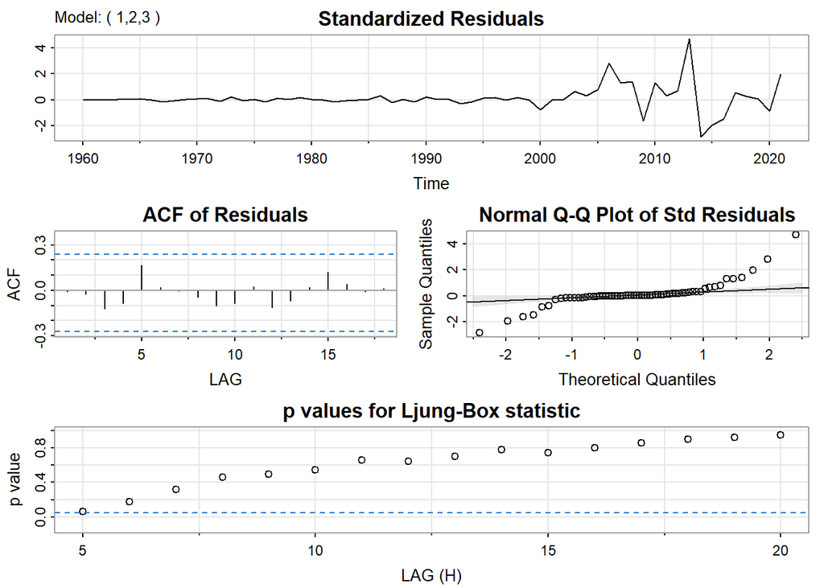

```r
sarima(train_ts, 1,2,3)
```

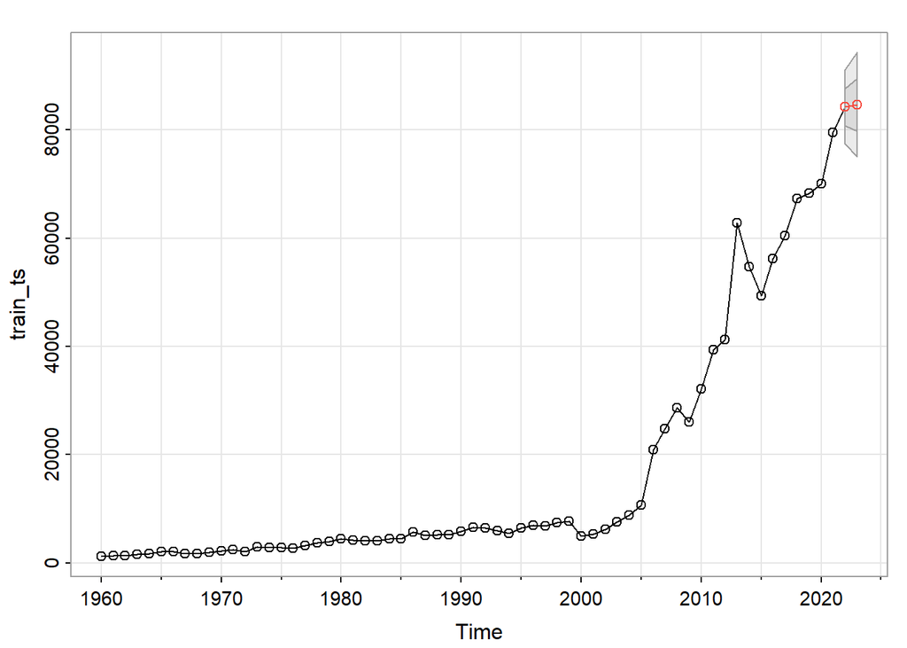

```r
fcast <- sarima.for(train_ts, 2,1,2,3)
```

Extract the forecast values from the forecast

```r
fcasted = fcast$pred
print(fcasted)
```

```
## Time Series:
## Start = 2022
## End = 2023
## Frequency = 1
## [1] 84255.56 84669.30
```

ARIMA forecasts a GDP of 84255.56 (million USD) for 2022 and 84669.30 (million USD) for 2023.

Now, we calculate evaluation metrics for the ARIMA model. We will Mean Absolute Error (MAE) and the Root Mean Square Error (RMSE) for this case.

```r
mae=mean(abs(fcasted - test_ts))
rmse=sqrt(mean((fcasted - test_ts)^2))
mae
```

```
## [1] 9145.93
```

```r
rmse
```

```
## [1] 9185.033
```

ARIMA performs with MAE of 9145.93 and RMSE of 9185.033

2. **Exponential Smoothing (ETS) Model**

We use the **ets** function from the **forecast** package to fit the Error, Trend and Seasonality components of the GDP series. We use the **train_ts** series to fit the model.

```r
ets_model=ets(train_ts)
ets_model
```

```
## ETS(M,A,N)
##
## Call:
##  ets(y = train_ts)
##
##   Smoothing parameters:
##     alpha = 0.9914
##     beta  = 0.1968
##
##   Initial states:
##     l = 1150.9004
##     b = 116.4928
##
##   sigma:  0.178
##
##      AIC     AICc      BIC
## 1146.318 1147.389 1156.953
```

Our **ets()** model identifies the ETS(M,A,N) model for this series. (M,A,N) stand for Multiplicative Error, Additive Trend, No seasonality; which is great because we are dealing with annual time series data that grows exponentially(trend).  
Residual Analysis for the fitted model.

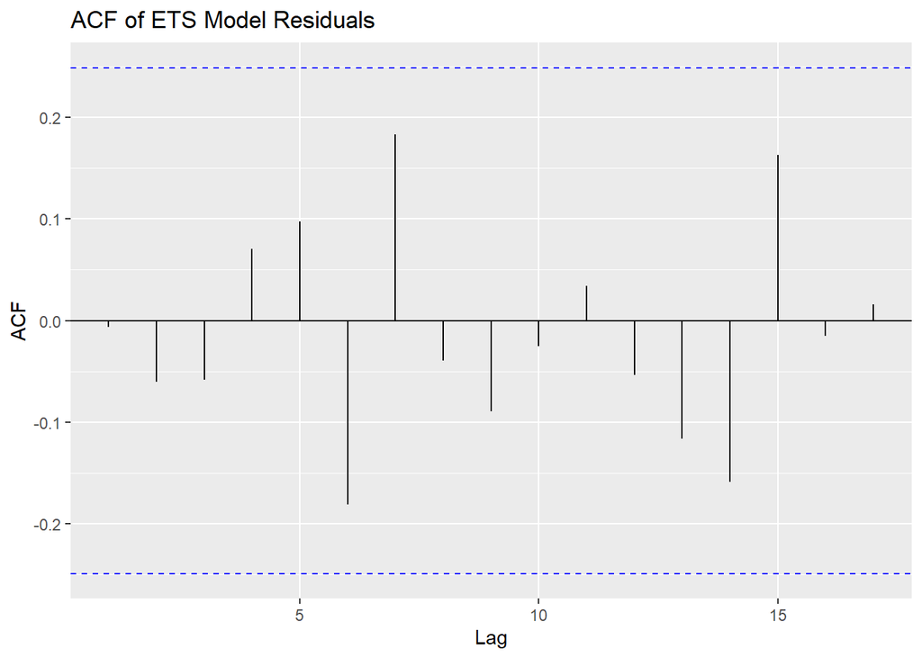

```r
ggAcf(residuals(ets_model)) +
  ggtitle("ACF of ETS Model Residuals") #ACF of the residuals
```

```r
Box.test(residuals(ets_model), lag = 10, type = "Ljung-Box") #ljung-box test of the residuals
```

```
##
##  Box-Ljung test
##
## data:  residuals(ets_model)
## X-squared = 6.994, df = 10, p-value = 0.726
```

Both the Ljung Box Test and the AutoCorrelation function plot of the residuals fulfill the assumptions taken for proper fitting and forecasting

We proceed to make forecasts using our fitted model

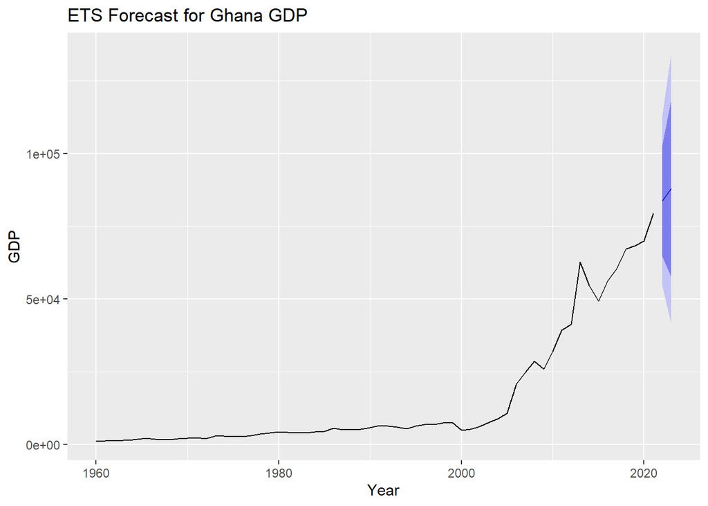

```r
ets_forecast=forecast(ets_model, h=2) #fprecast for a horizon of 2 years, 2022 and 2023
autoplot(ets_forecast, main = "ETS Forecast for Ghana GDP", ylab = "GDP", xlab = "Year") #plot of the forecast
```

Extract the forecast values by the model

```r
ets_fcasted=ets_forecast$mean
ets_fcasted
```

```
## Time Series:
## Start = 2022
## End = 2023
## Frequency = 1
## [1] 83796.57 88124.21
```

ETS forecasts a GDP of 83796.57 (million USD) for 2022 and 88124.21 (million USD) for 2023.

We compute the evaluation metrics for the Exponential Smoothing model

```r
ets_mae=mean(abs(ets_fcasted - test_ts))
ets_rmse=sqrt(mean((ets_fcasted - test_ts)^2))
ets_mae
```

```
## [1] 10643.89
```

```r
ets_rmse
```

```
## [1] 10701.64
```

ETS performs with MAE of 10643.89 and RMSE of 10701.64

3. **Prophet Model**

We start off with manipulating the annual GDP series to make it a dated time series data since Prophet works with dates and not just annual data.

```r
gdp_values=as.numeric(gdp_ts) #convert the series GDP values to numeric
years=time(gdp_ts) #extract the time(years) from the series
years_int=floor(years)
df_prophet=data.frame(
  ds = as.Date(paste0(years_int, "-12-31")),
  y = gdp_values
)                #a data frame for the new manupulated GDP series data with dates on years
df_prophet #view the new data frame
```

```
##            ds     y
## 1  1960-12-31  1217
## 2  1961-12-31  1303
## 3  1962-12-31  1383
## 4  1963-12-31  1541
## 5  1964-12-31  1731
## 6  1965-12-31  2053
## 7  1966-12-31  2126
## 8  1967-12-31  1747
## 9  1968-12-31  1667
## 10 1969-12-31  1962
## 11 1970-12-31  2215
## 12 1971-12-31  2417
## 13 1972-12-31  2112
## 14 1973-12-31  3007
```

[output cut: 50 more lines]

We split the new data frame into train and test data sets

```r
train_df=df_prophet[1:(nrow(df_prophet)-2), ] # the training set
test_df=df_prophet[(nrow(df_prophet)-1):nrow(df_prophet), ] #the testing set
```

We fit the Prophet Model on the **train_df** set.

```r
m=prophet(train_df)
```

```
## Disabling weekly seasonality. Run prophet with weekly.seasonality=TRUE to override this.
```

```
## Disabling daily seasonality. Run prophet with daily.seasonality=TRUE to override this.
```

```r
m # model fitting details
```

[output not shown]

[output cut: 293 more lines]

[output not shown]

We now make forecasts for the future. But first, we make a data frame to store them.

```r
future_df = make_future_dataframe(m, periods = 2, freq = "year") # data frame for the future forecast
forecast_prophet = predict(m, future_df) # forecasts
forecast_prophet
```

[output not shown]

[output cut: 245 more lines]

We perform Residual analysis for the Prophet model

```r
residuals_prophet <- as.numeric(train_df$y - forecast_prophet$yhat[1:nrow(train_df)])                 # residuals

resid_df <- data.frame(
  ds = as.Date(train_df$ds),
  residual = residuals_prophet
)                    # residuals data frame
```

We visualize the residuals to validate the forecasting assumptions

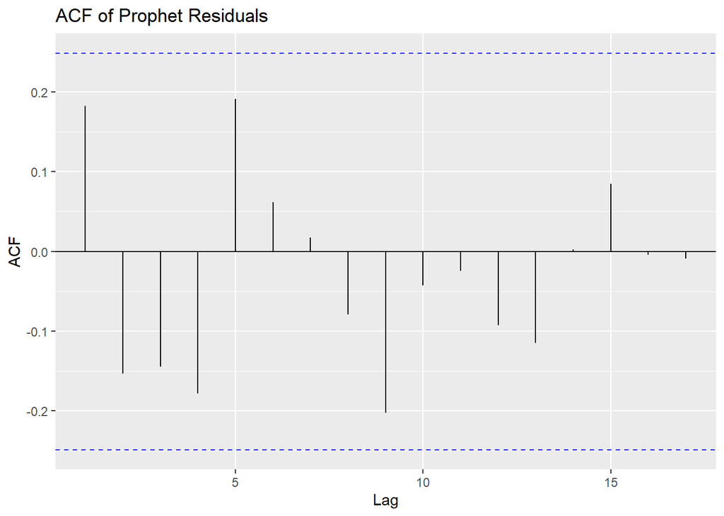

```r
ggAcf(residuals_prophet, main = "ACF of Prophet Residuals") #acf plot pf residuals
```

```r
Box.test(residuals_prophet, lag = 10, type = "Ljung-Box") #ljung box test for residuals
```

```
##
##  Box-Ljung test
##
## data:  residuals_prophet
## X-squared = 13.825, df = 10, p-value = 0.1811
```

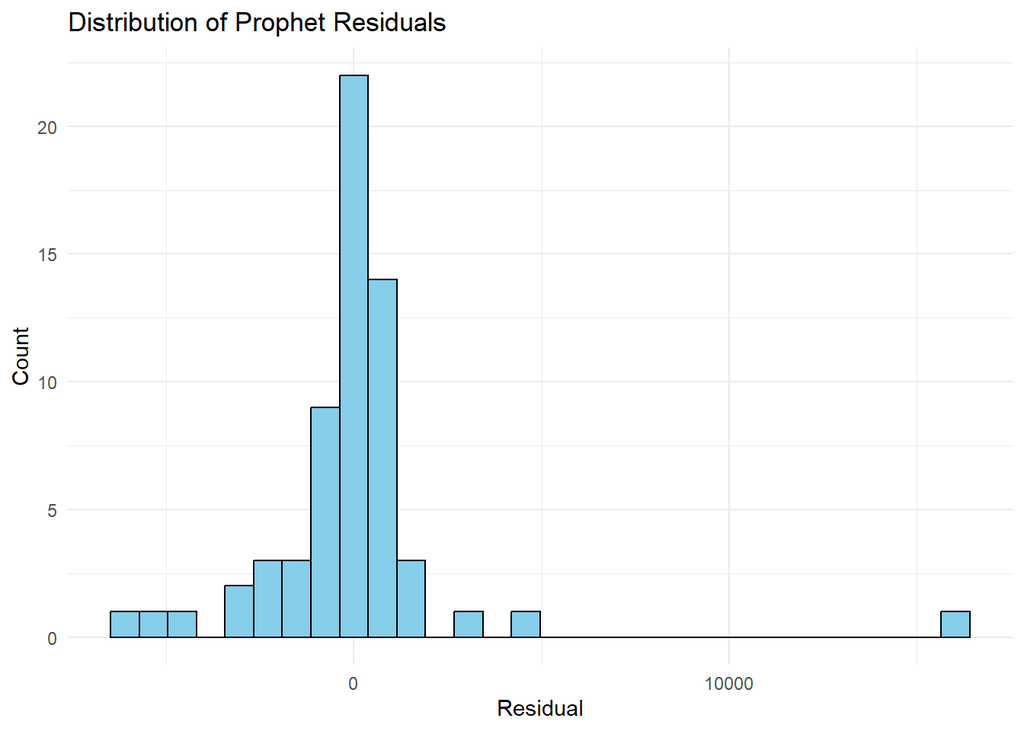

```r
ggplot(resid_df, aes(x = residual)) +
  geom_histogram(bins = 30, fill = "skyblue", color = "black") +
  labs(title = "Distribution of Prophet Residuals",
       x = "Residual", y = "Count") +
  theme_minimal()                          # residuals histogram
```

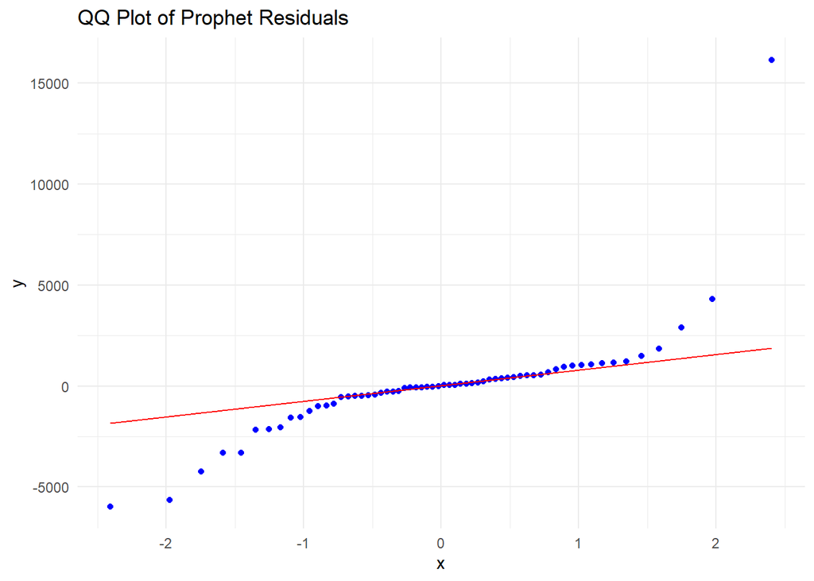

```r
ggplot(resid_df, aes(sample = residual)) +
  stat_qq(color = "blue") +
  stat_qq_line(color = "red") +
  labs(title = "QQ Plot of Prophet Residuals") +
  theme_minimal()      # qq plot of the residuals
```

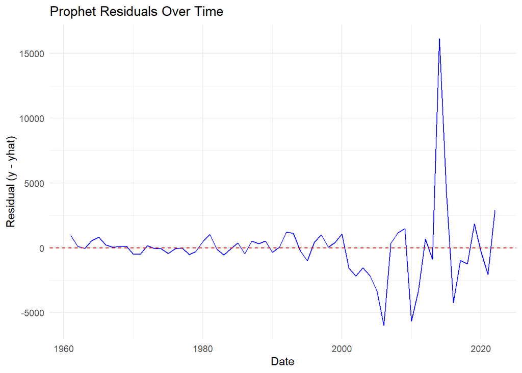

```r
ggplot(resid_df, aes(x = ds, y = residual)) +
  geom_line(color = "blue") +
  geom_hline(yintercept = 0, linetype = "dashed", color = "red") +
  labs(title = "Prophet Residuals Over Time",
       x = "Date", y = "Residual (y - yhat)") +
  theme_minimal()     #plot of model residuals over time
```

```r
fcasted_prophet=tail(forecast_prophet$yhat, 2)
fcasted_prophet
```

```
## [1] 80443.46 83588.38
```

Prophet predicts a GDP of 80443.46 (million USD) for 2022 and a GDP of 83588.38 (million USD) for 2023.

We go ahead to visualize these forecasts.

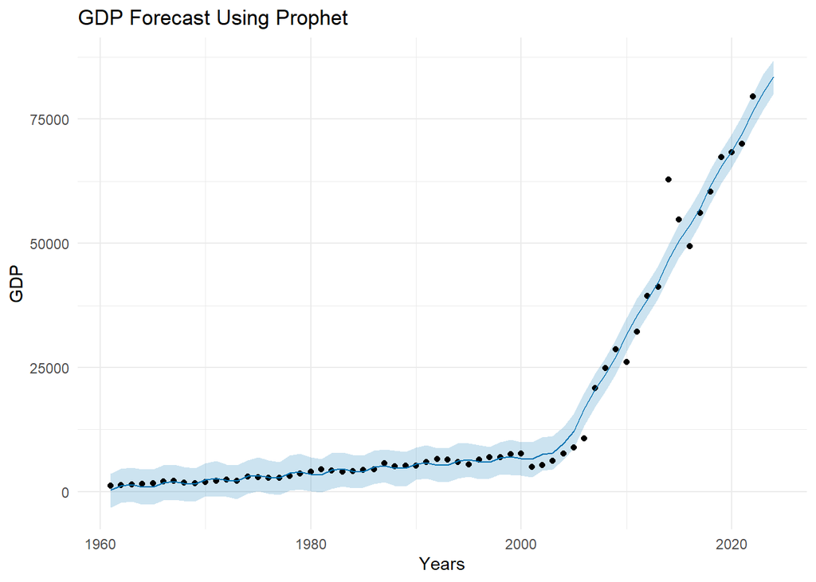

```r
plot(m, forecast_prophet) +
  ggtitle("GDP Forecast Using Prophet") +
  xlab("Years") +
  ylab("GDP") +
  theme_minimal()
```

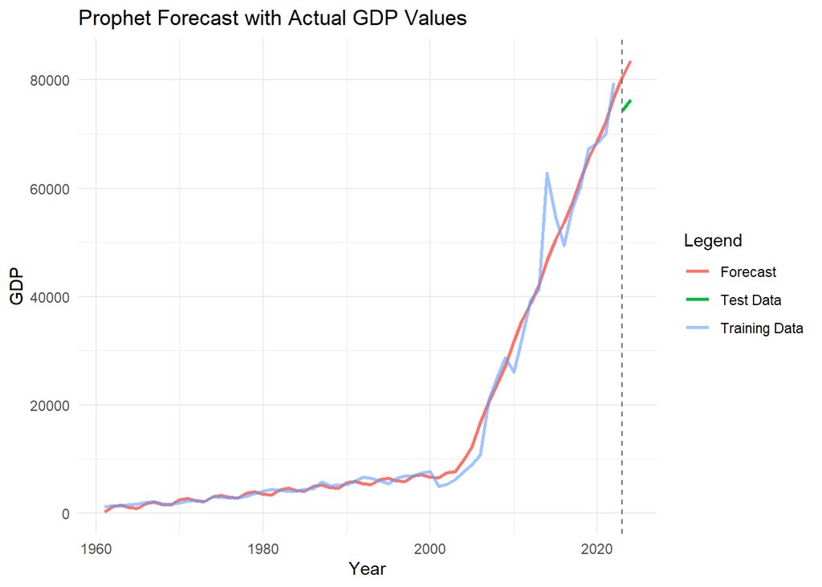

```r
split_date=as.POSIXct(min(test_df$ds))
ggplot() +
  geom_line(data = forecast_prophet, aes(x = as.POSIXct(ds), y = yhat, color = "Forecast"), size = 1) +
  geom_line(data = train_df, aes(x = as.POSIXct(ds), y = y, color = "Training Data"), size = 1, alpha = 0.6) +
  geom_line(data = test_df, aes(x = as.POSIXct(ds), y = y, color = "Test Data"), size = 1) +
  geom_vline(xintercept = split_date, linetype = "dashed", color = "gray40") +
  labs(
    title = "Prophet Forecast with Actual GDP Values",
    x = "Year",
    y = "GDP",
    color = "Legend"
  ) +
  theme_minimal()
```

We go ahead to get the performance metrics for the Prophet Model

```r
actuals_prophet=test_df$y
mae_prophet=mean(abs(fcasted_prophet - actuals_prophet))
rmse_prophet=sqrt(mean((fcasted_prophet - actuals_prophet)^2))
mae_prophet
```

```
## [1] 6699.417
```

```r
rmse_prophet
```

```
## [1] 6719.487
```

Prophet performs with MAE of 6699.417 and RMSE of 6719.487

To Summarize this analysis, I create a data frame to store all the performance metrics by each model

```r
results = data.frame(
  Model = c("ARIMA", "ETS", "Prophet"),
  MAE = c(mae, ets_mae, mae_prophet),
  RMSE = c(rmse, ets_rmse, rmse_prophet)
)
print(results)
```

```
##     Model       MAE      RMSE
## 1   ARIMA  9145.930  9185.033
## 2     ETS 10643.890 10701.645
## 3 Prophet  6699.417  6719.487
```

To rank the models by performance, here’s the ranking table.

| Model | MAE | RMSE |
| --- | --- | --- |
| Prophet | 6699.417 | 6719.487 |
| ARIMA | 9145.93 | 9185.03 |
| ETS | 10643.89 | 10701.645 |

Ghana should adopt modern machine learning forecasting models like Prophet to make more accurate forecasts to aid in making more efficient government economic plannings.

Although, this is in a government context, it can be applied well in business contexts. Businesses can adopt modern machine learning forecasting methods like Prophet to make forecasts for sales, supply, production and other business related time series variables to make more accurate predictions and plan more efficiently to make more informed business decisions.